# Basic Analytics 1

author: Dr. Marko Mitic

Problem Description: **STOCK DYNAMICS**

A stock market is where buyers and sellers trade shares of a company, and is one of the most popular ways for individuals and companies to invest money. The size of the world stock market is now estimated to be in the trillions. The largest stock market in the world is the New York Stock Exchange (NYSE), located in New York City. About 2,800 companies are listed on the NSYE. In this problem, we’ll look at the monthly stock prices of five of these companies: IBM, General Electric (GE), Procter and Gamble, Coca Cola, and Boeing. The data used in this problem comes from Infochimps.

Firstly, download and and read the following files into R, using the read.csv function: IBMStock.csv, GEStock.csv, ProcterGambleStock.csv, CocaColaStock.csv, and BoeingStock.csv. (Do not open these files in any spreadsheet software before completing this problem because it might change the format of the Date field.)

```r
IBM=read.csv("IBMStock.csv")
GE=read.csv("GEStock.csv")
ProcterGamble=read.csv("ProcterGambleStock.csv")
CocaCola=read.csv("CocaColaStock.csv")
Boeing=read.csv("BoeingStock.csv")
```

Each data frame has two variables, described as follows:

Date: the date of the stock price, always given as the first of the month. StockPrice: the average stock price of the company in the given month.

For example, the structure of the IBM dataset this can be veryfied as follows:

```r
str(IBM)
```

```
## 'data.frame':    480 obs. of  2 variables:
##  $ Date      : Factor w/ 480 levels "1/1/00","1/1/01",..: 11 171 211 251 291 331 371 411 451 51 ...
##  $ StockPrice: num  360 347 327 320 270 ...
```

Before working with these data sets, the dates in the dataframes need to be converted into formats that R can understand. We can convert this to a “Date” object in R by using the following five commands (one for each data set):

```r
IBM$Date = as.Date(IBM$Date, "%m/%d/%y")
GE$Date = as.Date(GE$Date, "%m/%d/%y")
CocaCola$Date = as.Date(CocaCola$Date, "%m/%d/%y")
ProcterGamble$Date = as.Date(ProcterGamble$Date, "%m/%d/%y")
Boeing$Date = as.Date(Boeing$Date, "%m/%d/%y")
```

Statistical summary give us insights on the first and last year in each data frame:

```r
summary(IBM)
```

```
##       Date              StockPrice
##  Min.   :1970-01-01   Min.   : 43.40
##  1st Qu.:1979-12-24   1st Qu.: 88.34
##  Median :1989-12-16   Median :112.11
##  Mean   :1989-12-15   Mean   :144.38
##  3rd Qu.:1999-12-08   3rd Qu.:165.41
##  Max.   :2009-12-01   Max.   :438.90
```

Mean, median and quantile stock values can be observed using this command. Next, let’s plot a graph to visualize stock price over the years (for CocaCola and Procter&Gamble companies).

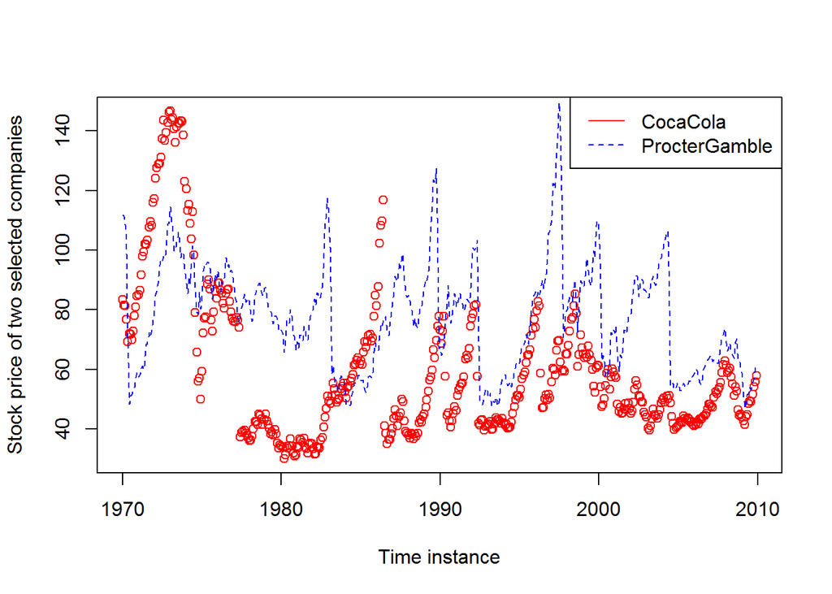

```r
plot(CocaCola$Date,CocaCola$StockPrice, col="red",
     xlab="Time instance", ylab="Stock price of two selected companies")
lines(ProcterGamble$Date,ProcterGamble$StockPrice, col="Blue", lty=2)
legend("topright", # places a legend at the appropriate place
       c("CocaCola", "ProcterGamble"), # puts text in the legend
       lty=c(1,2), # gives the legend appropriate symbols (lines)
       lwd=c(1,1),col=c("red","blue"))
```

From this plot, one can easily answer the questions about the highest and lowest stock price of a particular company. Using command `abline` as `abline(v=as.Date(c("2000-03-01")), lwd=2)`, the price around specific dates be further analized.

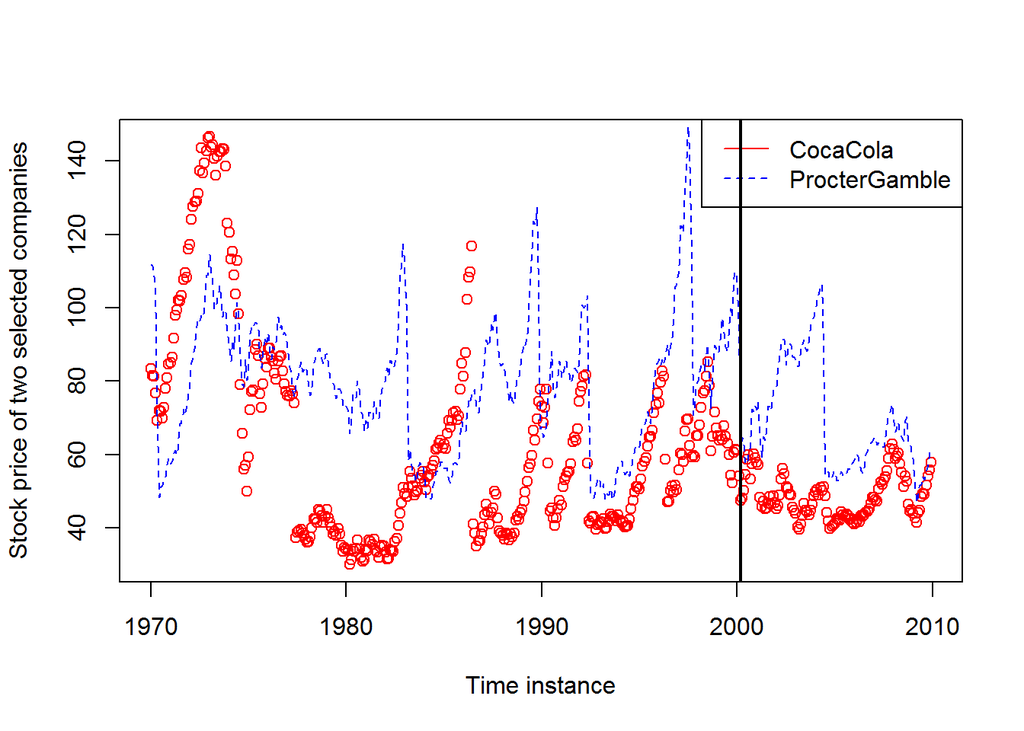

From new plot we can observe the stock price dropout of these selected companies during the technology bubble burst in March 2000. It is obvious that the Procter&Gamble company was affected more by this event.

The stock price change during time period 1995-2005 can be obtained with:

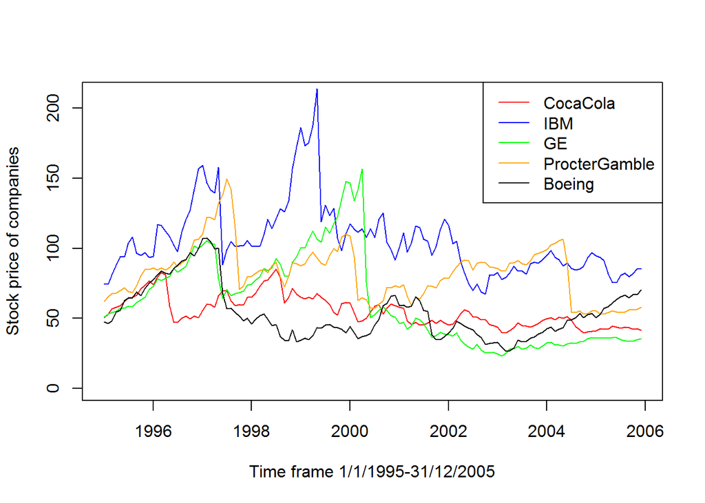

```r
plot(CocaCola$Date[301:432], CocaCola$StockPrice[301:432], type="l", col="red", ylim=c(0,210),
     xlab="Time frame 1/1/1995-31/12/2005", ylab="Stock price of companies")
lines(IBM$Date[301:432],IBM$StockPrice[301:432], col="Blue", lty=1)
lines(GE$Date[301:432],GE$StockPrice[301:432], col="Green", lty=1)
lines(ProcterGamble$Date[301:432],ProcterGamble$StockPrice[301:432], col="Orange", lty=1)
lines(Boeing$Date[301:432],Boeing$StockPrice[301:432], col="Black", lty=1)

legend("topright", # places a legend at the appropriate place
       c("CocaCola","IBM","GE", "ProcterGamble", "Boeing"), # puts text in the legend
       lty=c(1,1,1,1,1), # gives the legend appropriate symbols (lines)
       lwd=c(1,1,1,1,1),col=c("red","blue","green","orange","black"))
```

One can notice (with `abline` command) that stock price of GE company has fell the most right after March 2000. Also, it can be observed that stock of IBM reached the highest price in period 1995-2005.

In October of 1997, there was a global stock market crash that was caused by an economic crisis in Asia. Comparing September 1997 to November 1997, it can be concluded that Boeing and Procter&Gamble saw a decreasing trend in their stock price:

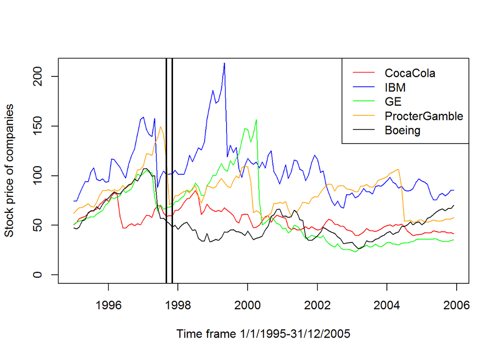

In the last two years of this time period (2004 and 2005) Boeing stock seems to be performing the best, in terms of increasing stock price.

Finally, let us analyze stock price behaviour by month. We can calculate mean prices (for example for IBM) using `tapply` function:

```r
tapply(IBM$StockPrice, months(IBM$Date), mean, na.rm=TRUE)
```

```
##     April    August  December  February   January      July      June
##  152.1168  140.1455  140.7593  152.6940  150.2384  139.0670  139.0907
##     March       May  November   October September
##  152.4327  151.5022  138.0187  137.3466  139.0885
```

```r
mean(IBM$StockPrice)
```

```
## [1] 144.375
```

```r
tapply(CocaCola$StockPrice, months(CocaCola$Date), mean, na.rm=TRUE)
```

```
##     April    August  December  February   January      July      June
##  62.68888  58.88014  59.73223  60.73475  60.36849  58.98346  60.81208
##     March       May  November   October September
##  62.07135  61.44358  59.10268  57.93887  57.60024
```

```r
tapply(GE$StockPrice, months(GE$Date), mean, na.rm=TRUE)
```

```
##     April    August  December  February   January      July      June
##  64.48009  56.50315  59.10217  62.52080  62.04511  56.73349  56.46844
##     March       May  November   October September
##  63.15055  60.87135  57.28879  56.23897  56.23913
```

```r
tapply(ProcterGamble$StockPrice, months(ProcterGamble$Date), mean, na.rm=TRUE)
```

```
##     April    August  December  February   January      July      June
##  77.68671  76.82266  78.29661  79.02575  79.61798  76.64556  77.39275
##     March       May  November   October September
##  77.34761  77.85958  78.45610  76.67903  76.62385
```

```r
tapply(Boeing$StockPrice, months(Boeing$Date), mean, na.rm=TRUE)
```

```
##     April    August  December  February   January      July      June
##  47.04686  46.86311  46.17315  46.89223  46.51097  46.55360  47.38525
##     March       May  November   October September
##  46.88208  48.13716  45.14990  45.21603  46.30485
```